# Your Digest for Tuesday, Jul 11, 2023 11:59 PM

#### Synthesis of thyroid hormone

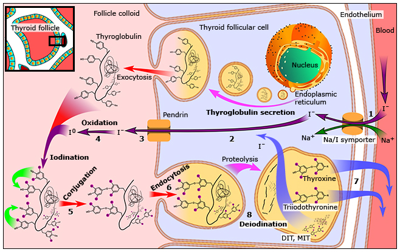

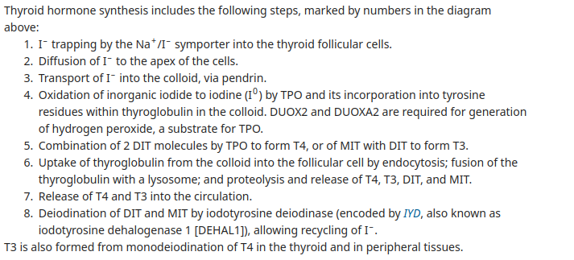

> [!INFO] *only unbound (FREE) thyroid hormones* can act on tissues.  
> *only unbound (FREE) thyroid hormones* can act on tissues. However, the protein bound fraction is very important for buffering and storage of thyroid hormone to prevent rapid fluctuations.

T3 binds to **nuclear recetpor** --> Exerts effects

## Functions of thyroid hormone

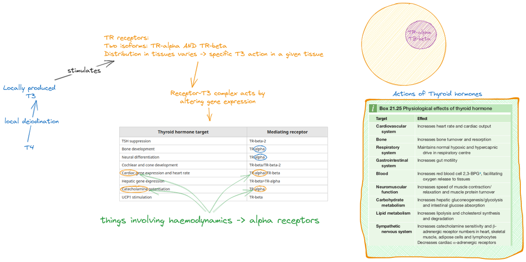

Thyroid hormone binds to it's **nuclear** receptors.  
There are two isoforms - TR alpha and beta, expressed in different tissues.  
Receptor-T3 complexes **alter gene expression**.  
Overall effects of T3:  
#2022BSQ Q23

| System | effect |
| --- | --- |
| CVS | Increase cardiac ouput |
| RS | Maintains respiratory drive |
| GI | increases motility |
| Blood | Incr. 23-DPG - increased oxygen unloading |
| Muscles | Increase speed of muscle contraction |
| Carbs | Increase gluconeogen, glycolysis, sugar absorption |
| lipid | Lipolysis + increased cholesterol turnover |
| Sympathetic NS | Increases expression of beta adrenergic receptors and in heart decreases alpha receptors |

# Pancreatic physiology

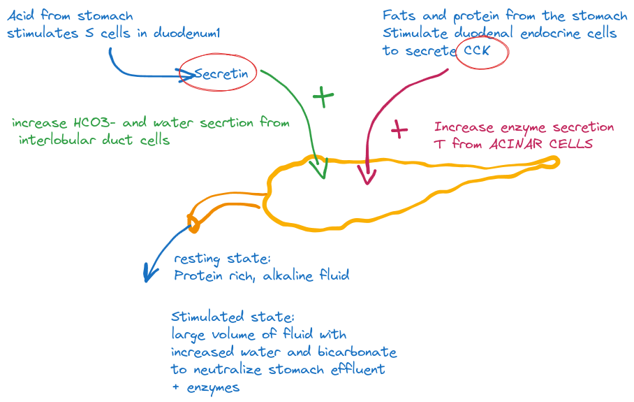

#2022BSQ Q24

Secretin and CCK are **endocrine** hormones.  
**Secretin** - role is to neutralize stomach effluent

- peptide hormone
- produced by **S cells of duodenum** and brain
- **inhibits gastrin release** -> to reduce stomach acid production
- Stimulates pancreatic secretion of fluid and bicarbonate  
  **Cholecystokinin** - promote pancreatic enzyme secretion

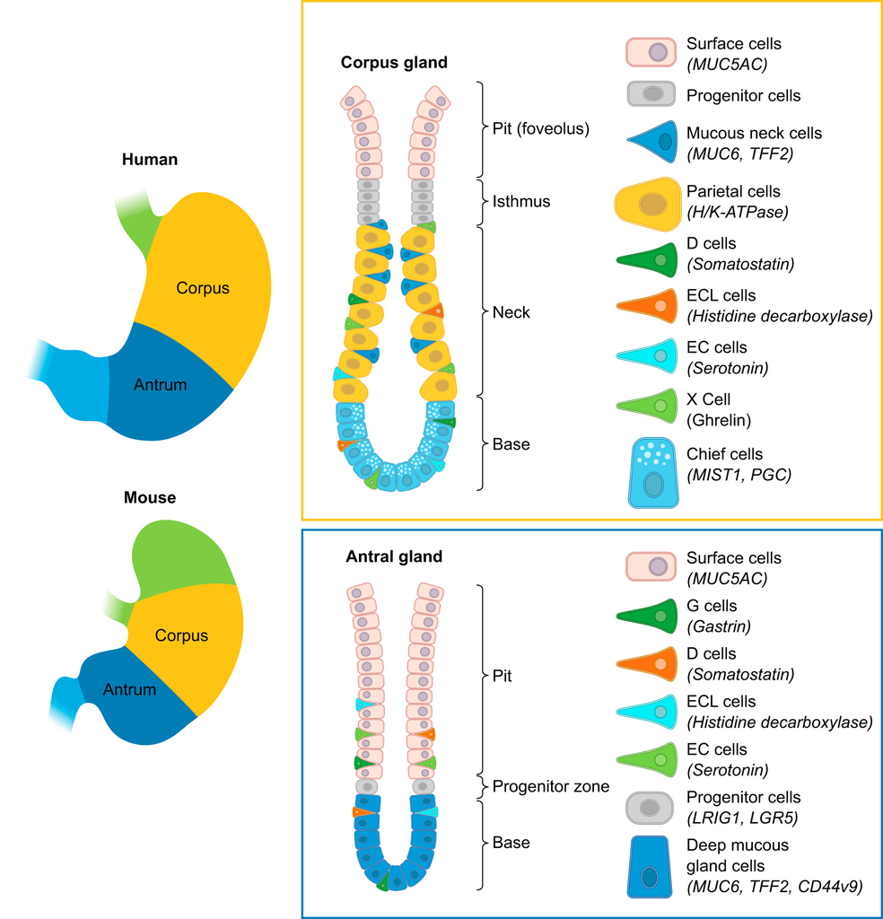

> [!INFO] Stomach gland distribution  
> Corpus (fundus + body) contains most of the oxyntic glands -> these produce acid (parietal cells) and pepsinogen (chief cells). They also contain **ghrelin secreting X cells**  
> The antrum contains mucous producing glands which uniquely contain **G cells**

Acid is Secreted by parietal cells. Parietal cells are present in **glands within the fundus and body of the stomach**.  
Regulation is by

1. *Endocrine* - Gastrin  
   3. Gastrin from **G cells** in the **antrum of the pylorus** stimulates histamine release from ECL cells (fundic glands)-> histamine stimulates acid secretion from parietal cells
   1. Somatostatin - **potent anti acid hormone**. Secreted by **D cells** located throughout gastric mucosa and from *oxyntic glands.* It inhibits histamine release -> reduces parietal cell acid production.  
      *Fundus and body* have **gastric glands** which have **chief cells at their bases**. Chief cells secrete **pepsinogen** which gets activated to pepsin in the low pH (<4) environment of the stomach. (Chief cells also produce gastric lipase)